# Recitation 5

```r
# Load libraries at the top of the .Rmd
library(tidyverse)
library(readxl)
library(data.table)
```

# Empirical Analysis of Energy Markets - U6616

## Empirical Exercise I - Data Exploration - Answer Key

### Intro

This problem set is due on October 2. I strongly recommend to start working on the homework early. I would suggest to plan on completing the first two parts by September 20. You can work in pairs and submit a common solution. Please submit the homework as an R markdown file (if there are data files, they put all the files in a zip file). The code must run without errors. To make this easier, set the working directory at the beginning so it can be easily changed by someone else running the code.

The purpose of this dataset is to analyze how the capacity of different fuels used to generate electricity in the United States has changed over time. We will also look at how emissions of different pollutants have changed and think about potential links between the two.

### Question 1

Start at the [EIA Electric Power Annual](https://www.eia.gov/electricity/annual/).

#### First download Tables 4.2.A and 4.2.B., which contain capacity by source over time.

I do this using code, but you could have just downloaded the excel files normally and put them in your R working directory (you figure this out by writing `getwd()`, or opening a new project in a particular folder) to complete this part.

```r
# Put the urls in a variable
urls <- c("https://www.eia.gov/electricity/annual/xls/epa_04_02_a.xlsx","https://www.eia.gov/electricity/annual/xls/epa_04_02_b.xlsx")
# Where do I want to store the data and outputs for the whole exercise?
# educational note: "." means current working directory, check your current working directory with getwd()
data_folder <- "data"
output_folder <- "output"
download_file <- function(url){
  #' Function to download and unzip.
  # Input
  print(url)
  # file name
  print(basename(url))
  # concatenate the filename to your data storage
  fname <- file.path(data_folder, basename(url))
  print(fname)
  # If the file doesn't exist download it, otherwise just return where it's stored.
  if (!file.exists(fname)){
    download.file(url, fname)
  }
  return(fname)
}
# Create those folders if they don't exist
invisible(dir.create(file.path(".", data_folder), showWarnings = T))
```

```
'./data' already exists
```

```r
invisible(dir.create(file.path(".", output_folder), showWarnings = T))
```

```
'./output' already exists
```

```r
# Use the function
fnames <- c(download_file(urls[1]),download_file(urls[2]))
```

```
[1] "https://www.eia.gov/electricity/annual/xls/epa_04_02_a.xlsx"
[1] "epa_04_02_a.xlsx"
[1] "data/epa_04_02_a.xlsx"
[1] "https://www.eia.gov/electricity/annual/xls/epa_04_02_b.xlsx"
[1] "epa_04_02_b.xlsx"
[1] "data/epa_04_02_b.xlsx"
```

#### Load the files to R and describe each variable. Make sure to use the appropriate class for each variable.

- Loading the files is easiest using the ‘import dataset’ function, or navigating to the file in the lower right hand side, finding and clicking the file and hitting import dataset from the drop-down menu.
- By use the appropriate class, we mean that the data type of the variable should be appropriate for analysis.
- Anticipating the future questions, you only needed to load the first 12 rows of each file.
- You could describe each variable in the data-type sense with `str()`, or in the statistical sense with `summary()`. Bonus points given for doing both.
- Using int or date are both acceptable for dealing with years (ints are easier, the advantage of dates is allowing you to deal with leap years, counting number of days across years and months, etc)

##### Describe each variable:

Year is self-described, each of the other columns is the capacity in MW for each energy source.

[output not shown]

```
NAs introduced by coercionNAs introduced by coercion
```

```
Classes ‘data.table’ and 'data.frame':  11 obs. of  12 variables:
 $ Year                        : int  2008 2009 2010 2011 2012 2013 2014 2015 2016 2017 ...
 $ Coal                        : num  313322 314294 316800 317640 309680 ...
 $ Petroleum                   : num  57445 56780 55647 51482 47167 ...
 $ Natural Gas                 : num  397460 401272 407028 415191 422364 ...
 $ Other Gases                 : num  1995 1932 2700 1934 1946 ...
 $ Nuclear                     : num  100755 101004 101167 101419 101885 ...
 $ Hydroelectric Conventional  : num  77930 78518 78825 78652 78738 ...
 $ Other Renewable Sources     : num  38466 48552 53811 61221 77155 ...
 $ Hydroelectric Pumped Storage: num  21858 22160 22199 22293 22368 ...
 $ Other Energy Sources        : num  942 888 884 1420 1729 ...
 $ Utility Total               : num  1010171 1025400 1039062 1051251 1063033 ...
 $ Estimated Photovoltaic      : num  NA NA NA NA NA ...
 - attr(*, ".internal.selfref")=<externalptr>
Classes ‘data.table’ and 'data.frame':  11 obs. of  11 variables:
 $ Year                                       : int  2008 2009 2010 2011 2012 2013 2014 2015 2016 2017 ...
 $ Wind                                       : num  24651 34296 39134 45676 59075 ...
 $ Solar Photovoltaic                         : num  70.8 145.5 393.4 1052 2694.1 ...
 $ Solar Thermal                              : num  465 473 473 472 476 ...
 $ Wood and Wood-Derived Fuels                : num  6864 6939 7037 7076 7508 ...
 $ Geothermal                                 : num  2229 2382 2405 2409 2592 ...
 $ Other Biomass                              : num  4186 4316 4368 4536 4811 ...
 $
Total Utility (Other Renewable Sources): num  38466 48552 53811 61221 77155 ...
 $ Estimated Small Scale Photovoltaic         : num  NA NA NA NA NA ...
 $ Total Solar Photovoltaic                   : num  70.8 145.5 393.4 1052 2694.1 ...
 $ Total Solar                                : num  536 618 866 1524 3170 ...
 - attr(*, ".internal.selfref")=<externalptr>
      Year           Coal          Petroleum      Natural Gas      Other Gases      Nuclear
 Min.   :2008   Min.   :242786   Min.   :32218   Min.   :397460   Min.   :1914   Min.   : 98569
 1st Qu.:2010   1st Qu.:273170   1st Qu.:35606   1st Qu.:411110   1st Qu.:1940   1st Qu.: 99337
 Median :2013   Median :303306   Median :43523   Median :425390   Median :2108   Median : 99629
 Mean   :2013   Mean   :292710   Mean   :44538   Mean   :428487   Mean   :2219   Mean   :100122
 3rd Qu.:2016   3rd Qu.:313808   3rd Qu.:53564   3rd Qu.:443124   3rd Qu.:2479   3rd Qu.:101086
 Max.   :2018   Max.   :317640   Max.   :57445   Max.   :470237   Max.   :2700   Max.   :101885

 Hydroelectric Conventional Other Renewable Sources Hydroelectric Pumped Storage Other Energy Sources Utility Total
 Min.   :77930              Min.   : 38466          Min.   :21858                Min.   : 883.8       Min.   :1010171
 1st Qu.:78695              1st Qu.: 57516          1st Qu.:22246                1st Qu.:1180.8       1st Qu.:1045156
 Median :79200              Median : 82600          Median :22389                Median :1795.6       Median :1063033
```

[output cut: 20 more lines]

```
 Other Biomass  \r\nTotal Utility (Other Renewable Sources) Estimated Small Scale Photovoltaic Total Solar Photovoltaic
 Min.   :4186   Min.   : 38466                              Min.   : 7327                      Min.   :   70.8
 1st Qu.:4452   1st Qu.: 57516                              1st Qu.: 9778                      1st Qu.:  722.7
 Median :5039   Median : 82600                              Median :12765                      Median : 5336.1
 Mean   :4801   Mean   : 86231                              Mean   :13113                      Mean   :15576.5
 3rd Qu.:5107   3rd Qu.:111325                              3rd Qu.:16148                      3rd Qu.:27321.0
 Max.   :5166   Max.   :142474                              Max.   :19547                      Max.   :49667.6
                                                            NA's   :6
  Total Solar
 Min.   :  535.6
 1st Qu.: 1195.0
 Median : 6622.5
 Mean   :16698.6
 3rd Qu.:29078.8
 Max.   :51425.5
```

#### What is capacity? Make sure you understand the difference between capacity and generation.

*Capacity* The maximum electric power output (rate of energy generation, or energy over time) that can be output from a power plant.

These datasets use ‘Net Summer Capacity’, which is [“the maximum output, commonly expressed in megawatts (MW), that generating equipment can supply to system load, as demonstrated by a multi-hour test, at the time of summer peak demand (period of June 1 through September 30.”](https://www.eia.gov/tools/glossary/index.php?id=net%20summer%20capacity)

*Generation* is a measure of energy, not power (the derivative of energy over time), and is calculated with a formula like this:

$$\sum_i power_i*time_i$$

where each i refers to a different level of power generation that can be of any length. For example, if a 10MW natural gas plant produces its capacity (10MW) for 12 hours, half-capacity (5MW) for 6 hours, and is turned off for 6 hours, the generation is:

$$10MW*12h + 5MW * 6h + 0MW*6h = 150MWh.$$

Another term you hear relating these tho things is the **capacity factor**, which unintuitively is a ratio of actual *generation* over the *total theoretical generation*. Using the same example, the total theoretical annual generation of the 10MW natural gas plant is $10MW *24hrs/day*365 days/year$, so if in a year the plant produces 40000MWh of energy, its capacity factor would be
$$\frac{40000MWh}{10 MW * 24hrs/day*365 days/year} = 45.6\%$$
.

#### Plot total capacity over time. How has this changed?

Extra points for readable/converted units, and for x scale that doesn’t have .5s.

Total capacity increases over time, From 2008 - 2012, in increases by about 50 GW, and from 2015 to 2018 it increases by about 35 GW. It stays about constant from 2012-2016. The increases put together only constitute about 8% of the initial capacity.

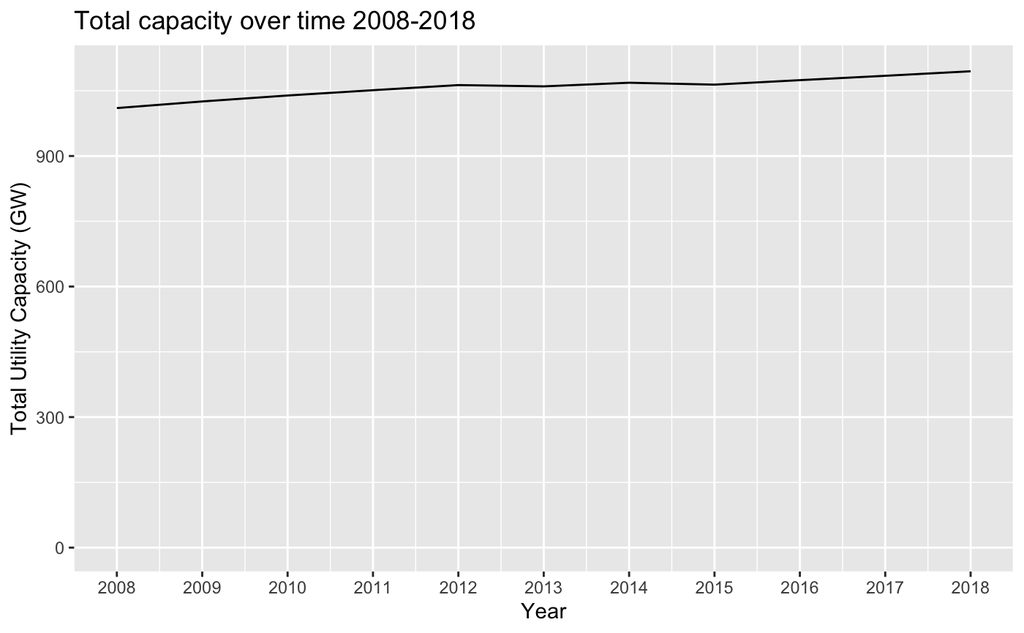

```r
# Make the plot GW for more readability!
plot1 <- ggplot(a , mapping = aes(x = Year, y = `Utility Total`/1000))+
  geom_line()+
  # Zoomed in version
  # limits set the bounds of the y axis
  scale_y_continuous(name = "Total Utility Capacity (GW)", limits = c(1000,1100)) +
  # make every year labeled
  scale_x_continuous(n.breaks = 10) +
  ggtitle("Total capacity over time 2008-2018")
ggsave("output/capacity2008-2018.png")
# Show the absolute value on the y axis so you don't exagerrate the difference.
# If you are using the same data, you can overwrite parameters for the plot this way:
plot2 <- plot1 + scale_y_continuous(name = "Total Utility Capacity (GW)", limits = c(0,1100))
ggsave("output/capacity_absolute2008-2018.png")
plot2
```

#### Plot the share of capacity from the different sources over time. How has this changed?

It’s really important here to realize that we ask you to use both tables, and that means you don’t want to double count. High-level algorithm: 1. Join tables 2. Remove double-counted columns 3. Plot share using a stacked bar or area graph

It’s nice to use intuitive colors for fuels.

```r
# These aren't necessary because dt is smart, but you should set keys before joins to build good habits
setkey(a, Year)
setkey(b, Year)
# Join
dt1 <- merge(a,b)
dt1
```

| Year | Coal | Petroleum | Natural Gas | Other Gases | Nuclear | Hydroelectric Conventional | Other Renewable Sources | Hydroelectric Pumped Storage | Other Energy Sources | Utility Total | Estimated Photovoltaic | Wind | Solar Photovoltaic | Solar Thermal | Wood and Wood-Derived Fuels | Geothermal | Other Biomass | Total Utility (Other Renewable Sources) | Estimated Small Scale Photovoltaic | Total Solar Photovoltaic | Total Solar |
| --- | --- | --- | --- | --- | --- | --- | --- | --- | --- | --- | --- | --- | --- | --- | --- | --- | --- | --- | --- | --- | --- |
| 2008 | 313322.0 | 57445.0 | 397460.0 | 1995.0 | 100755.0 | 77930.0 | 38466.0 | 21858.0 | 942.0 | 1010171 | NA | 24651.0 | 70.8 | 464.8 | 6864.0 | 2229.0 | 4186.0 | 38466.0 | NA | 70.8 | 535.6 |
| 2009 | 314294.1 | 56780.5 | 401271.8 | 1932.4 | 101003.7 | 78517.7 | 48552.0 | 22160.4 | 887.8 | 1025400 | NA | 34295.8 | 145.5 | 473.0 | 6939.3 | 2381.9 | 4316.5 | 48552.0 | NA | 145.5 | 618.5 |
| 2010 | 316800.1 | 55646.9 | 407028.4 | 2700.3 | 101167.4 | 78824.7 | 53811.3 | 22198.9 | 883.8 | 1039062 | NA | 39134.5 | 393.4 | 473.0 | 7037.3 | 2404.6 | 4368.5 | 53811.3 | NA | 393.4 | 866.4 |
| 2011 | 317640.3 | 51481.6 | 415191.3 | 1934.2 | 101418.8 | 78651.6 | 61221.0 | 22292.6 | 1419.6 | 1051251 | NA | 45675.9 | 1052.0 | 471.5 | 7076.5 | 2409.2 | 4535.9 | 61221.0 | NA | 1052.0 | 1523.5 |
| 2012 | 309680.4 | 47167.2 | 422364.4 | 1945.6 | 101885.0 | 78738.0 | 77155.2 | 22368.3 | 1728.9 | 1063033 | NA | 59074.8 | 2694.1 | 476.0 | 7507.6 | 2592.1 | 4810.6 | 77155.2 | NA | 2694.1 | 3170.1 |
| 2013 | 303306.3 | 43523.0 | 425389.7 | 2107.8 | 99240.3 | 79200.0 | 82600.1 | 22389.3 | 2307.0 | 1060064 | NA | 59973.4 | 5336.1 | 1286.4 | 8354.2 | 2607.0 | 5043.0 | 82600.1 | NA | 5336.1 | 6622.5 |
| 2014 | 299094.2 | 41135.4 | 432150.3 | 1914.3 | 98569.3 | 79677.3 | 90603.7 | 22485.1 | 2792.6 | 1068422 | 7326.6 | 64231.5 | 8656.6 | 1666.7 | 8368.1 | 2514.3 | 5166.5 | 90603.7 | 7326.6 | 15983.2 | 17649.9 |
| 2015 | 279719.9 | 36830.3 | 439425.4 | 2500.4 | 98672.0 | 79664.2 | 102871.6 | 22575.1 | 1795.6 | 1064054 | 9778.5 | 72573.4 | 11905.4 | 1757.9 | 8968.9 | 2541.5 | 5124.5 | 102871.6 | 9778.5 | 21683.9 | 23441.8 |
| 2016 | 266619.9 | 34382.4 | 446823.2 | 2456.9 | 99564.8 | 79912.9 | 119778.9 | 22778.7 | 2015.1 | 1074333 | 12765.1 | 81286.6 | 20192.9 | 1757.9 | 8936.1 | 2516.6 | 5088.8 | 119778.9 | 12765.1 | 32958.0 | 34715.9 |
| 2017 | 256547.3 | 33306.7 | 456011.6 | 2375.8 | 99628.9 | 79794.5 | 131008.1 | 22810.4 | 2886.3 | 1084370 | 16147.8 | 87597.5 | 25209.0 | 1757.9 | 8830.9 | 2483.3 | 5129.5 | 131008.1 | 16147.8 | 41356.8 | 43114.7 |

[output cut: 1 more lines]

```r
# Remove double counted columns and totals
# Print possible columns
# names(dt1)
# List of sources you should remove
remove <- c("Utility Total","Estimated Photovoltaic","Other Renewable Sources","\r\nTotal Utility (Other Renewable Sources)","Total Solar Photovoltaic","Total Solar")
# Syntax tip
# DT[,Cols.Chosen:=NULL] Delete the column with column name Cols.chosen
# DT[,(Cols.Chosen):=NULL] Delete the columns specified in the variable Cols.chosen
# Remove these columns
dt1[,(remove) := NULL]
# Melt the columns down to plot
dt1 <- melt(dt1, "Year")
dt1
```

| Year | variable | value |
| --- | --- | --- |
| 2008 | Coal | 313322.0 |
| 2009 | Coal | 314294.1 |
| 2010 | Coal | 316800.1 |
| 2011 | Coal | 317640.3 |
| 2012 | Coal | 309680.4 |
| 2013 | Coal | 303306.3 |
| 2014 | Coal | 299094.2 |
| 2015 | Coal | 279719.9 |
| 2016 | Coal | 266619.9 |
| 2017 | Coal | 256547.3 |

[output cut: 155 more lines]

```r
# You might get this error:     Removed 6 rows containing missing values (position_stack),
# that's because there's no data for Estimated Small Scale Photovoltaic before 2014.
dt1[is.na(value)]
```

| Year | variable | value |
| --- | --- | --- |
| 2008 | Estimated Small Scale Photovoltaic | NA |
| 2009 | Estimated Small Scale Photovoltaic | NA |
| 2010 | Estimated Small Scale Photovoltaic | NA |
| 2011 | Estimated Small Scale Photovoltaic | NA |
| 2012 | Estimated Small Scale Photovoltaic | NA |
| 2013 | Estimated Small Scale Photovoltaic | NA |

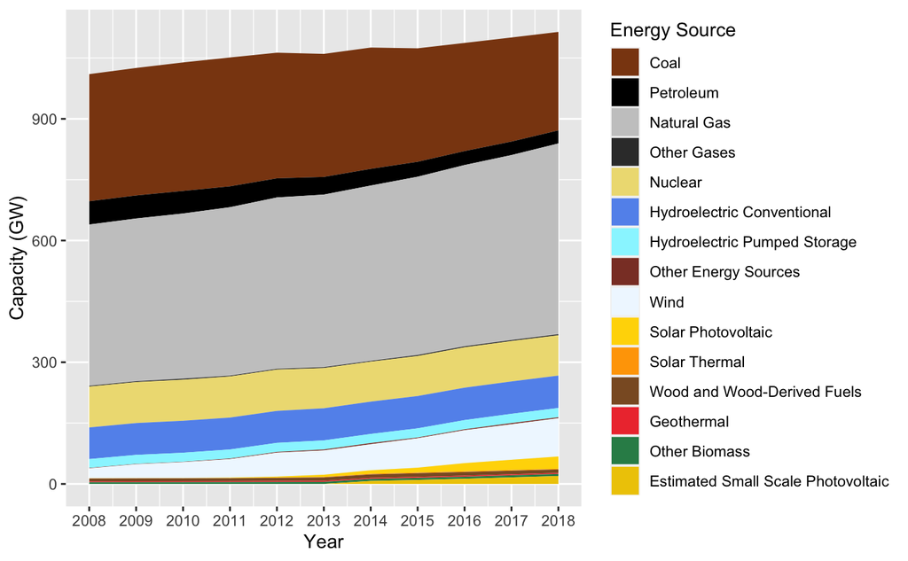

```r
# You can reasonably assume it's 0
dt1[is.na(value), value := 0]
# Plot
# There's a color cheat sheet here, or you can use hex codes if you know them
# http://sape.inf.usi.ch/quick-reference/ggplot2/colour
ggplot(dt1, aes(x = Year, y = value/1000, fill = variable)) +
  geom_area() +
  scale_x_continuous(n.breaks= 10) +
  scale_y_continuous(name = "Capacity (GW)") +
  scale_fill_manual(name = "Energy Source", values=c("chocolate4", "black", "gray79","gray22", 'lightgoldenrod','cornflowerblue',"cadetblue1", "coral4", 'aliceblue','gold', "orange","tan4", 'brown2', "seagreen", "gold2"))
ggsave(file.path(output_folder, 'part1_capacity.pdf'), width = 16, height = 9)
```

### Question 2

Now we will obtain data on emissions over time. For this, follow [this link](https://www.eia.gov/totalenergy/data/browser/index.php?tbl=T11.06) to the EIA Monthly Energy Review. Section 11 contains data on many emissions sources, but just download the data set on carbon emissions from energy consumption in the electric power sector (11.6).

There was some confusion about this filetype - T11.06 is in fact a csv/excel file depending on which version you downloaded. But it didn’t have the .xls or .csv at the end of the file, so some detective work was needed to figure this out. Either loading it directly, or changing the filename to add .csv or .xls at the end was necessary.

### Load the files to R and describe each variable. Make sure to use the appropriate class for each variable.

This question needs either a datatype description or a statistical description. YYYYMM could be int, could be parsed to a date, or split into two ints.

```r
 ##################
# Emissions by year
# Download the file using the function defined in q1.
fname <- download_file("https://www.eia.gov/totalenergy/data/browser/csv.php?tbl=T11.06")
```

```
[1] "https://www.eia.gov/totalenergy/data/browser/csv.php?tbl=T11.06"
[1] "csv.php?tbl=T11.06"
[1] "data/csv.php?tbl=T11.06"
```

```r
# Load a csv
em <-  fread(fname)
# data type and statistical description
str(em)
```

```
Classes ‘data.table’ and 'data.frame':  5553 obs. of  6 variables:
 $ MSN         : chr  "CLEIEUS" "CLEIEUS" "CLEIEUS" "CLEIEUS" ...
 $ YYYYMM      : int  197301 197302 197303 197304 197305 197306 197307 197308 197309 197310 ...
 $ Value       : chr  "72.076" "64.442" "64.084" "60.842" ...
 $ Column_Order: int  1 1 1 1 1 1 1 1 1 1 ...
 $ Description : chr  "Coal Electric Power Sector CO2 Emissions" "Coal Electric Power Sector CO2 Emissions" "Coal Electric Power Sector CO2 Emissions" "Coal Electric Power Sector CO2 Emissions" ...
 $ Unit        : chr  "Million Metric Tons of Carbon Dioxide" "Million Metric Tons of Carbon Dioxide" "Million Metric Tons of Carbon Dioxide" "Million Metric Tons of Carbon Dioxide" ...
 - attr(*, ".internal.selfref")=<externalptr>
```

```r
summary(em)
```

```
     MSN                YYYYMM          Value            Column_Order Description            Unit
 Length:5553        Min.   :197301   Length:5553        Min.   :1     Length:5553        Length:5553
 Class :character   1st Qu.:198412   Class :character   1st Qu.:3     Class :character   Class :character
 Mode  :character   Median :199610   Mode  :character   Median :5     Mode  :character   Mode  :character
                    Mean   :199630                      Mean   :5
                    3rd Qu.:200808                      3rd Qu.:7
                    Max.   :202006                      Max.   :9
```

```r
em
```

| MSN | YYYYMM | Value | Column_Order | Description | Unit |
| --- | --- | --- | --- | --- | --- |
| CLEIEUS | 197301 | 72.076 | 1 | Coal Electric Power Sector CO2 Emissions | Million Metric Tons of Carbon Dioxide |
| CLEIEUS | 197302 | 64.442 | 1 | Coal Electric Power Sector CO2 Emissions | Million Metric Tons of Carbon Dioxide |
| CLEIEUS | 197303 | 64.084 | 1 | Coal Electric Power Sector CO2 Emissions | Million Metric Tons of Carbon Dioxide |
| CLEIEUS | 197304 | 60.842 | 1 | Coal Electric Power Sector CO2 Emissions | Million Metric Tons of Carbon Dioxide |
| CLEIEUS | 197305 | 61.798 | 1 | Coal Electric Power Sector CO2 Emissions | Million Metric Tons of Carbon Dioxide |
| CLEIEUS | 197306 | 66.538 | 1 | Coal Electric Power Sector CO2 Emissions | Million Metric Tons of Carbon Dioxide |
| CLEIEUS | 197307 | 72.626 | 1 | Coal Electric Power Sector CO2 Emissions | Million Metric Tons of Carbon Dioxide |
| CLEIEUS | 197308 | 75.181 | 1 | Coal Electric Power Sector CO2 Emissions | Million Metric Tons of Carbon Dioxide |
| CLEIEUS | 197309 | 68.397 | 1 | Coal Electric Power Sector CO2 Emissions | Million Metric Tons of Carbon Dioxide |
| CLEIEUS | 197310 | 67.668 | 1 | Coal Electric Power Sector CO2 Emissions | Million Metric Tons of Carbon Dioxide |

[output cut: 990 more lines]

```r
# Get the year and month by getting the quotient and remainder after dividing by 100
em[, `:=`(year = YYYYMM%/%100, month =  YYYYMM%%100)]
# Get the annual data which is coded as the 13th month in this dataset
em <-  em[!grepl('total',Description, ignore.case = TRUE) & month==13]
# Check everything is in the same units, convert to factor
em[,c('Unit', 'Description','Value'):= list(as.factor(Unit),as.factor(Description),as.numeric(Value))]
```

```
NAs introduced by coercion
```

```r
# Make missing values 0
em[is.na(Value), Value := 0]
```

#### Plot total emissions over time. How have they changed?

Total Emissions from the electricity grid have risen slowly by about 1 billion metric tons since the 1970s until a peak in 2005. Then it falls back to the 1970s levels in 2020 ‘decarbonization’. Note that this isn’t total energy in the US, but just power plants. The transport sector has not decarbonized by as much.

The difference between this and the next question is to just to a line graph and a stacked area/bar chart separately. Bonus points for relabelling axes to billion metric tons, marks for title, axes labels.

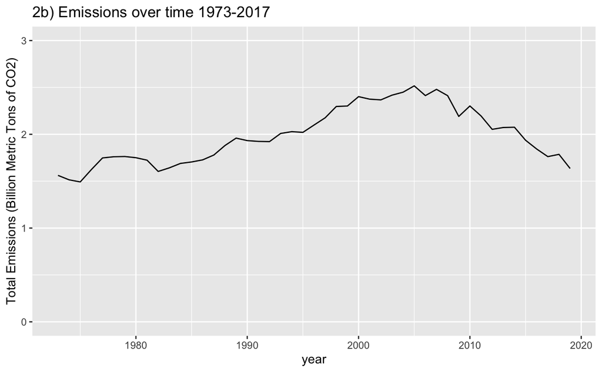

```r
setkey(em, year)
em_total <- em[,.(`Total Emissions`=sum(Value)),by = key(em)]
ggplot(em_total, aes(x = year, y = `Total Emissions`/1000)) +
  geom_line() +
  scale_y_continuous(name = "Total Emissions (Billion Metric Tons of CO2)", limits = c(0,3)) +
  ggtitle('2b) Emissions over time 1973-2017')
```

#### Plot the share of emissions from the different sources over time. How has this changed? How do you relate this to what you observed in the previous question?

Since 2005, natural gas has rapidly increased while coal has decreased. This has meant that electricity generation has substituted coal emissions for natural gas emissions. We can’t tell whether coal plants have totally been replaced or not yet, that’s part 3 - is the drop in emissions due to coal being replaced by natural gas? or renewables? What proportion?

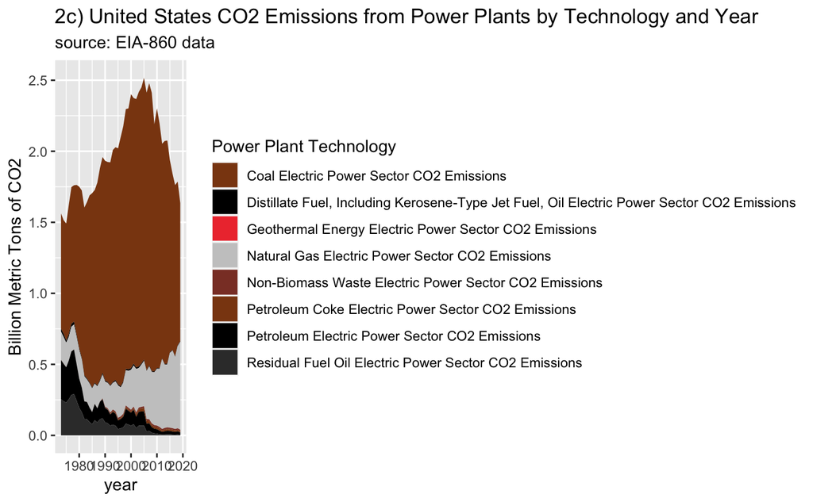

```r
# Plot emissions over time by technology of generator
ggplot(em, aes(x= year, y = Value/1000, fill = Description))+
  geom_area(position = 'stack') +
  ggtitle("2c) United States CO2 Emissions from Power Plants by Technology and Year", subtitle = "source: EIA-860 data") +
  ylab("Billion Metric Tons of CO2") +
  scale_fill_manual(name = "Power Plant Technology", values=c("chocolate4", "black", 'brown2',"gray79","coral4","chocolate4","black","gray22"))
ggsave(file.path(output_folder, 'emissions.pdf'), width = 16, height = 9)
```

### Question 3

Since the previous dataset only had capacity for 10 years, the next step is to download data from EIA Form 860 to build capacity for a period as long as the one for emissions.

#### Follow the steps covered during recitation to build the total capacity of source for each year.

These are just the steps from recitation, I end up showing students part 3a-c.

##### Download and unzip file

```r
# This dataset is no longer the early release version!
url <- "https://www.eia.gov/electricity/data/eia860/xls/eia8602019.zip"
# I want a variable for the name of my data folder
data_folder <-  "data"
# Create the folde if it doesn't exist
dir.create(file.path(".", data_folder), showWarnings = T)
```

```
'./data' already exists
```

```r
# Get the path of the file when it is stored on disk
fname <- file.path(data_folder, basename(url))
fname
```

```
[1] "data/eia8602019.zip"
```

```r
# If the file doesn't exist already, download from the URL (the web) to the path (your computer's folder called data, relative to your working directory)
if (!file.exists(fname)){
  download.file(url, fname)
}
# Unzip the folder
unzip(fname, exdir = data_folder)
```

##### Look and examine the data

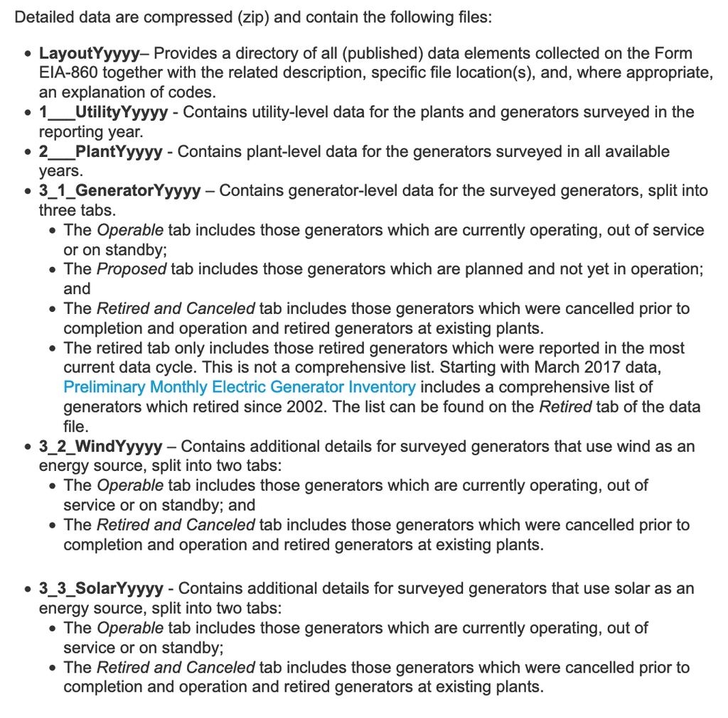

- What is the difference between 1, 2 and 3?

the relevant data is in 3

- What is the difference between 3.1 and 3.2…

“Additional Details” are in 3_2+, these we don’t need because the capacity, technology, and the operating and retirement years are in 3_1.

- Look at the data we want, is it sufficient to answer the question?

…build capacity for a period as long as the one for emissions

##### Assumption

We don’t need any more data. Assume:

- All power plants in ‘Operable’ are still ‘active’ and have been active since “Operating Year”
- All power plants in ‘Retired and Cancelled’ were ‘active’ from “Operating Year” until “Retirement Year”, and that this dataset is exhaustive.
- Power plant capacity in any given year is the total capacity of ‘active’ plants.

##### 2 methods

- Have a column with active status…
- Keep a running tally for each fuel and year.
- What is the minimum dataset we need for each method?

##### High-level algorithm for the running tally method

My ideal dataset has a cumulative capacity for each technology-year pair.

1. For all those power plants are operable, we assume they are active up until the current year, so they never go offline.
2. For all those power plants in ‘Retired and Cancelled’, we assume they are active between their operating and retirement years; if there’s no data, we just assume they are cancelled and never operated.
3. Get the sum of Power Plant Capacity that came online in each year from the Operating Year column - ‘additions’ - by technology.
4. Get the sum of Power Plant Capacity that was retired/came offline from the Retirement Year column - ‘subtractions’ - in each year by technology.
5. The ‘net capacity change’ for each technology-year pair is additions less subtractions.
6. Running a cumulative sum over the years by technology will give me the total capacity by technology in each year.

##### Join vs Concatenate?

- Concatenating (rbindlist) is stacking two datasets
- Joining (merge, join) is putting two datsets next to each other
- Which do we want to do here?

Concatenate

- Which columns are important to do correctly?

The minimum dataset has Operating Year, Retirement Year, Nameplate Capacity (MW), and Technology.

```r
# Read in the data after unzipping
fname <- file.path(data_folder, "3_1_Generator_Y2019.xlsx")
# Import the excel sheet using Import Dataset in RStudio.
operable <-  as.data.table(read_excel(fname, sheet = "Operable", skip = 1, na = 'NA'))
```

[output not shown]

[output not shown]

[output not shown]

[output not shown]

[output not shown]

[output not shown]

[output not shown]

[output not shown]

[output not shown]

[output not shown]

[output not shown]

[output not shown]

[output not shown]

[output not shown]

[output not shown]

[output not shown]

```r
# Look at structure
str(operable)
```

```
Classes ‘data.table’ and 'data.frame':  22731 obs. of  73 variables:
 $ Utility ID                                                             : num  63560 63560 63560 63560 63560 ...
 $ Utility Name                                                           : chr  "TDX Sand Point Generating, LLC" "TDX Sand Point Generating, LLC" "TDX Sand Point Generating, LLC" "TDX Sand Point Generating, LLC" ...
 $ Plant Code                                                             : num  1 1 1 1 1 1 2 3 3 3 ...
 $ Plant Name                                                             : chr  "Sand Point" "Sand Point" "Sand Point" "Sand Point" ...
 $ State                                                                  : chr  "AK" "AK" "AK" "AK" ...
 $ County                                                                 : chr  "Aleutians East" "Aleutians East" "Aleutians East" "Aleutians East" ...
 $ Generator ID                                                           : chr  "1" "2" "3" "5" ...
 $ Technology                                                             : chr  "Petroleum Liquids" "Petroleum Liquids" "Petroleum Liquids" "Petroleum Liquids" ...
 $ Prime Mover                                                            : chr  "IC" "IC" "IC" "IC" ...
 $ Unit Code                                                              : chr  NA NA NA NA ...
 $ Ownership                                                              : chr  "S" "S" "S" "S" ...
 $ Duct Burners                                                           : chr  "X" "X" "X" "X" ...
 $ Can Bypass Heat Recovery Steam Generator?                              : chr  "X" "X" "X" "X" ...
 $ RTO/ISO LMP Node Designation                                           : chr  NA NA NA NA ...
```

[output cut: 60 more lines]

```r
# View the table
head(operable)
```

| Utility ID | Utility Name | Plant Code | Plant Name | State | County | Generator ID | Technology | Prime Mover | Unit Code | Ownership | Duct Burners | Can Bypass Heat Recovery Steam Generator? | RTO/ISO LMP Node Designation | RTO/ISO Location Designation for Reporting Wholesale Sales Data to FERC | Nameplate Capacity (MW) | Nameplate Power Factor | Summer Capacity (MW) | Winter Capacity (MW) | Minimum Load (MW) | Uprate or Derate Completed During Year | Month Uprate or Derate Completed | Year Uprate or Derate Completed | Status | Synchronized to Transmission Grid | Operating Month | Operating Year | Planned Retirement Month | Planned Retirement Year | Associated with Combined Heat and Power System | … |
| --- | --- | --- | --- | --- | --- | --- | --- | --- | --- | --- | --- | --- | --- | --- | --- | --- | --- | --- | --- | --- | --- | --- | --- | --- | --- | --- | --- | --- | --- | --- |
| 63560 | TDX Sand Point Generating, LLC | 1 | Sand Point | AK | Aleutians East | 1 | Petroleum Liquids | IC | NA | S | X | X | NA | NA | 0.9 | 0.8 | 0.4 | 0.4 | 0.4 | N | NA | NA | SB | Y | 12 | 2000 | NA | NA | N | … |
| 63560 | TDX Sand Point Generating, LLC | 1 | Sand Point | AK | Aleutians East | 2 | Petroleum Liquids | IC | NA | S | X | X | NA | NA | 0.9 | 0.8 | 0.3 | 0.3 | 0.3 | N | NA | NA | OP | X | 12 | 2000 | NA | NA | N | … |
| 63560 | TDX Sand Point Generating, LLC | 1 | Sand Point | AK | Aleutians East | 3 | Petroleum Liquids | IC | NA | S | X | X | NA | NA | 0.5 | 0.8 | 0.3 | 0.3 | 0.3 | N | NA | NA | OA | X | 12 | 2010 | NA | NA | N | … |
| 63560 | TDX Sand Point Generating, LLC | 1 | Sand Point | AK | Aleutians East | 5 | Petroleum Liquids | IC | NA | S | X | X | NA | NA | 0.7 | 0.8 | 0.4 | 0.3 | 0.3 | N | NA | NA | OA | X | 12 | 2000 | NA | NA | N | … |
| 63560 | TDX Sand Point Generating, LLC | 1 | Sand Point | AK | Aleutians East | WT1 | Onshore Wind Turbine | WT | NA | S | X | X | NA | NA | 0.5 | 0.89 | 0.1 | 0.1 | 0.1 | N | NA | NA | OA | X | 10 | 2011 | NA | NA | N | … |
| 63560 | TDX Sand Point Generating, LLC | 1 | Sand Point | AK | Aleutians East | WT2 | Onshore Wind Turbine | WT | NA | S | X | X | NA | NA | 0.5 | 0.89 | 0.3 | 0.3 | 0.3 | N | NA | NA | OP | X | 10 | 2011 | NA | NA | N | … |